# Course Proj 1

Leonardo78rs

05/04/2019

# Statistical Inference Course Project 1

## Overview

Part 1: Instruções Gerais da Simulação

Neste projeto, nós vamos investigar a distribuição exponencial com o R, e depois comparar com o Teorema do Limite Central.

A distribuição exponencial pode ser simulada com R utilizando rexp(n, lambda), onde a variável lambda é a taxa de parâmetro.

A média da distribuição exponencial é 1/lambda, bem como o desvio padrão também é 1/lambda.

## Simulations (1000 random of 40 exp)

[figure not shown]

```r
# load ggplot2
library(ggplot2)
# set constants
lambda <- 0.1
n <- 40 # exponetials
QuantSimul <- 1000 # quant of tests
# set the seed to create reproducability
set.seed(1507446545)
# Running in N versus QuantSimul matrix
ExpDistrib      <- matrix(data=rexp(n * QuantSimul, lambda), nrow=QuantSimul)
ExpDistribMeans <- data.frame(means=apply(ExpDistrib, 1, mean))
```

## Giving sample Mean versus Theoretical Mean

Note that the expected mean $\mu$ of a exponential distribution of rate $\lambda$ is

$\mu= \frac{1}{\lambda}$

```r
mu <- 1/lambda
mu
```

```
## [1] 10
```

Let $\bar X$ be the average sample mean of 1000 simulations of 40 randomly sampled distributions.

```r
GrandMeans <- mean(ExpDistribMeans$means)
GrandMeans
```

```
## [1] 10.04108
```

The expected mean is very close of the avarage sample mean.

## Sample Variance versus Theoretical Variance

The expected standard deviation $\sigma$ of a exponential distribution of rate $\lambda$ is

$\sigma = \frac{1/\lambda}{\sqrt{n}}$

```r
sd <- (1/lambda)/sqrt(n)
sd
```

```
## [1] 1.581139
```

The $Variance$ of standard deviation $\sigma$ is

$Variance = \sigma^2$

```r
Variance <- sd^2
Variance
```

```
## [1] 2.5
```

- $Variance_x$ is the variance of the average sample mean of 1000 simulations of 40 randomly distributed;
- $\sigma_x$ the corresponding standard deviation.

```r
sd_x <- sd(ExpDistribMeans$means)
sd_x
```

```
## [1] 1.589317
```

```r
Variance_x <- var(ExpDistribMeans$means)
Variance_x
```

```
## [1] 2.52593
```

The standard deviations are almost close together.

## Distribution and Population means

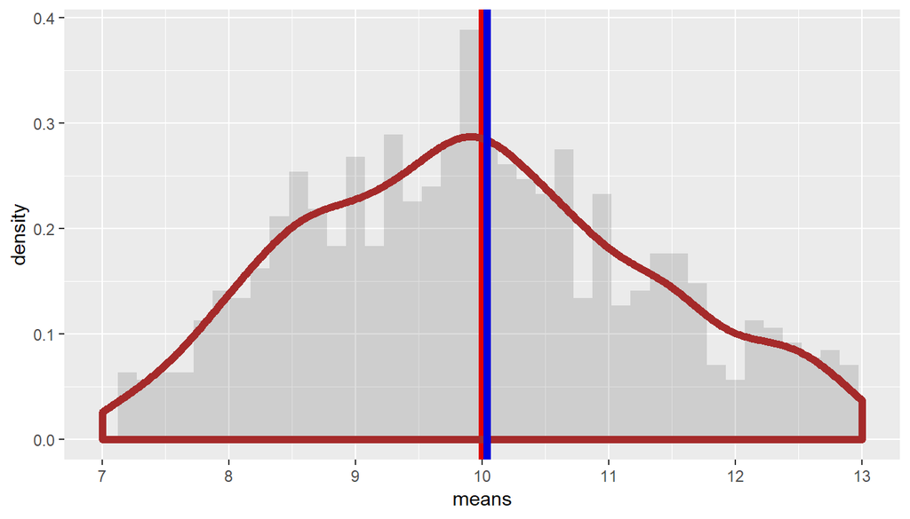

```r
# plot
ggplot(data = ExpDistribMeans, aes(x = means)) +
  geom_histogram(binwidth=0.15, aes(y=..density..), alpha=0.2) +
  stat_function(fun = dnorm, arg = list(mean = mu , sd = sd), colour = "blue", size=1) +
  geom_vline(xintercept = mu, size=2, colour="#DD0000") +
  geom_density(colour="brown", size=2) +
  geom_vline(xintercept = GrandMeans, size=2, colour="#0000DD") +
  scale_x_continuous(breaks=seq(mu-3,mu+3,1), limits=c(mu-3,mu+3))
```